# Coursework Report

*N* removed NAs: 3

*N* removed typo: 1

*N* removed <18: 15

*N* total clean: 131

| Group | *N* | *M*<sub>age</sub> | *M*<sub>rating</sub> |
| --- | --- | --- | --- |
| Control | 68 | 20.7 | 5.61 |
| Experim | 63 | 21.0 | 6.43 |

**Main analysis results**

[interactive chart not shown]

[figure not shown]

[interactive chart not shown]

# Coursework Report

Analysing Data, Spring 2020

# Methods

## Design

The research question that was investigated in this study was: does colour influence attractiveness? To answer this, attractiveness as a dependent variable was evaluated using three items – questions related to their opinion of the person in the picture. The items were: “how attractive is the person in the photo?”, “how pleasant do you find this person to look at?” and “upon meeting in person, I would think they are attractive”. Each of these items were measured using a 9-point scale in which 1 represented that the participant did not find the person attractive at all, and oppositely, 9 meant they found the person extremely attractive. Therefore, if a participant reports a lower rating on the scale, they do not find the person in the image to be very attractive. The answers on the rating scales were averaged to find a composite score. It was hypothesised that people would report higher ratings of attractiveness for the three items if the subject in the picture was displayed with a red frame in comparison to a white frame. This hypothesis will be tested using the t-test to identify whether there is a difference in the sample means compared to the standard error of the differences in means.

# Results

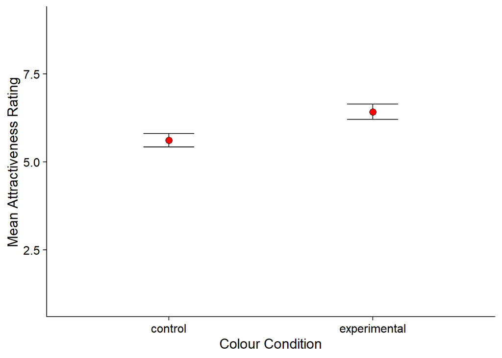

From the graph above there appears to be a difference in the mean attractiveness rating scores between the control and experimental group with the experimental group producing a higher mean attractiveness rating (6.4) compared to the control group (5.6). However, as small differences are common when comparing two sample means, the t-test was also conducted to see whether the differences were significant.

```
##
##  Two Sample t-test
##
## data:  rating_comp by GROUP
## t = -5, df = 110, p-value = 0.0000004
## alternative hypothesis: true difference in means is not equal to 0
## 95 percent confidence interval:
##  -1.102 -0.508
## sample estimates:
##      mean in group control mean in group experimental
##                       5.61                       6.42
```